# Heatmap of foldchanges

3. Visualize the data in the CO2 dataset in a way that gives you a deeper understanding of the data. What do you see?

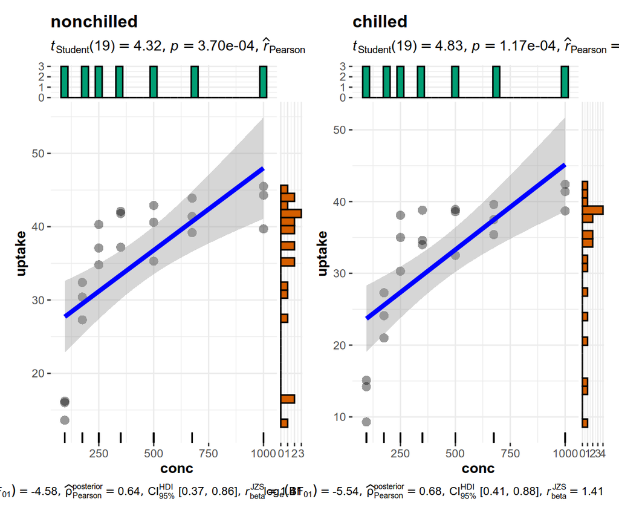

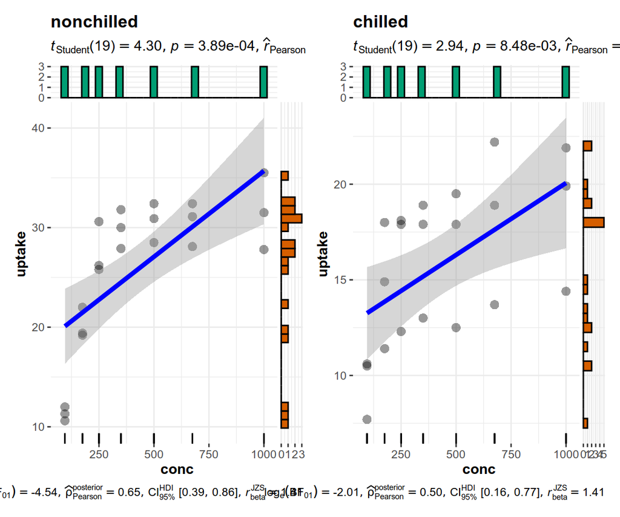

```r
CO2.split <- split(CO2, CO2$Type)
lapply(CO2.split, function(x) {grouped_ggscatterstats(
  data             = x,
  x                = conc,
  y                = uptake,
  type             = "parametric",
  grouping.var     = Treatment,
  ggplot.component = list(geom_rug(sides = "b"))
)})
```

```r
data(chromosome)
select(chromosome, c(variations, protein_codinggenes, mi_rna)) |> summary()
```

```
#>    variations       protein_codinggenes     mi_rna
#>  Min.   :  211643   Min.   :  71.0      Min.   : 15.00
#>  1st Qu.: 4395298   1st Qu.: 595.8      1st Qu.: 55.75
#>  Median : 6172346   Median : 836.0      Median : 75.00
#>  Mean   : 6484572   Mean   : 850.0      Mean   : 73.17
#>  3rd Qu.: 8742592   3rd Qu.:1055.5      3rd Qu.: 92.00
#>  Max.   :12945965   Max.   :2058.0      Max.   :134.00
```

2. How does the chromosome size distribute? Plot a graph that helps to visualize this by using ggplot2 package functions.

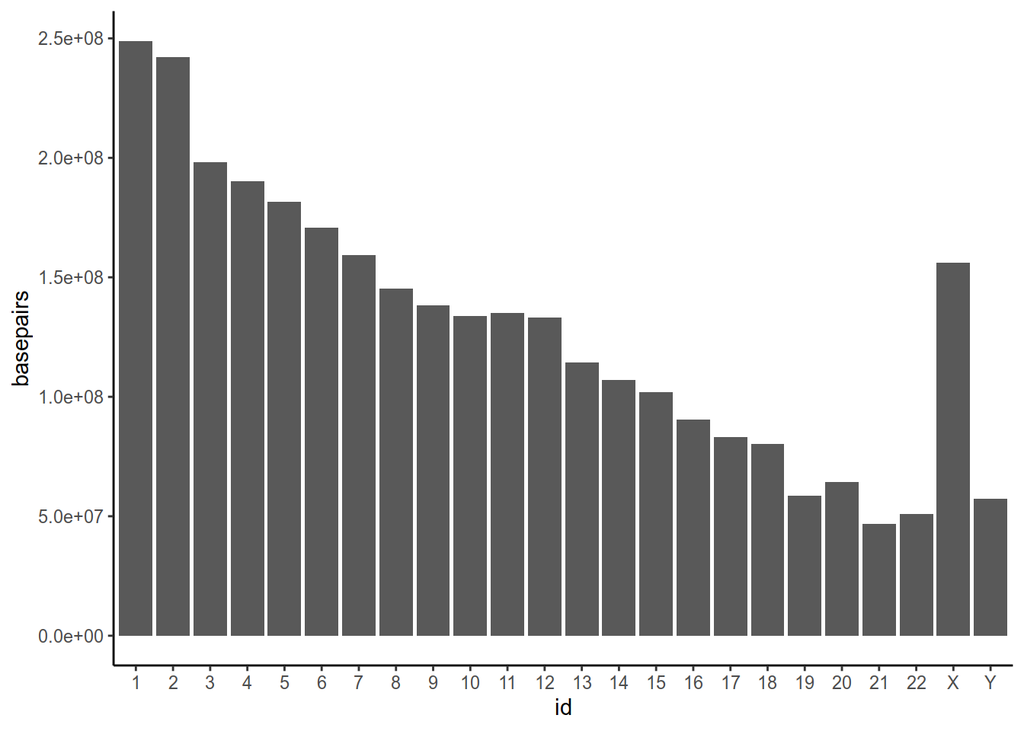

```r
ggplot(chromosome, aes(x = id, y=basepairs)) +
  geom_bar(stat="identity") + theme_classic()
```

3. Does the number of protein coding genes or miRNAs correlate with the length of the chromosome? Make two separate plots to visualize these relationships.

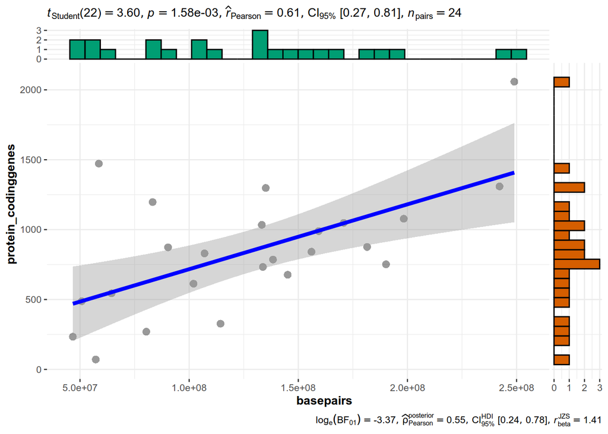

```r
ggscatterstats(
  data             = chromosome,
  x                = basepairs,
  y                = protein_codinggenes,
  type             = "parametric"
)
```

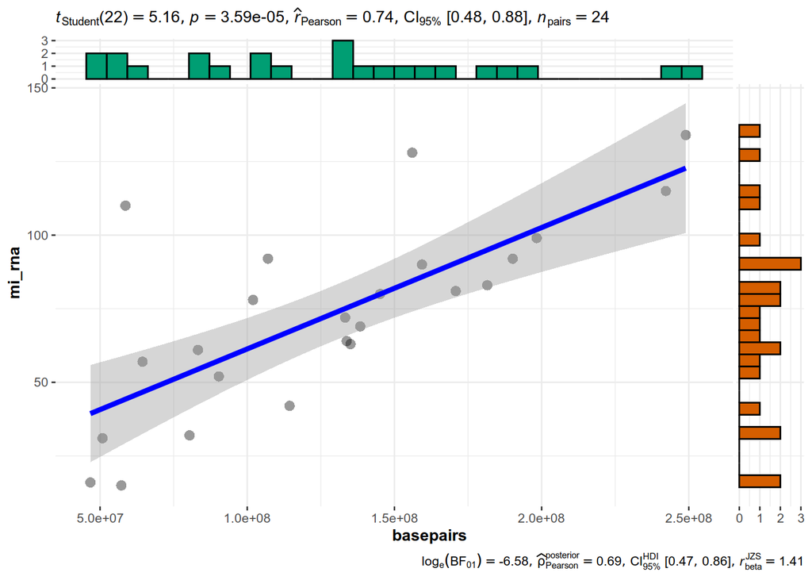

```r
ggscatterstats(
  data             = chromosome,
  x                = basepairs,
  y                = mi_rna,
  type             = "parametric"
)
```

>Yes

4. Calculate the same summary statistics for the ‘proteins’ data variables length and mass. Create a meaningful visualization of the relationship between these two variables by utilizing the ggplot2 package functions. Play with the colors, theme- and other visualization parameters to create a plot that pleases you.

```r
data(proteins)
proteins |> select(length, mass) |> summary()
```

```
#>      length             mass
#>  Min.   :    2.0   Min.   :    260
#>  1st Qu.:  251.0   1st Qu.:  27940
#>  Median :  414.0   Median :  46140
#>  Mean   :  557.2   Mean   :  62061
#>  3rd Qu.:  669.0   3rd Qu.:  74755
#>  Max.   :34350.0   Max.   :3816030
```

```r
ggscatterstats(
  data             = proteins,
  x                = length,
  y                = mass,
  type             = "parametric"
)
```

[figure not shown]